# DG-ToG-Donation Analysis

Pagano S. & Guido A.

23/02/2022

# Search criteria

The selection criteria to identify papers in target was:

- **Game type** (cooperation and prosociality games):
  - Dictator Game
  - Take or Give Game
  - Donation Game
- Presence of norm elicitation task:
  - Krupka and Weber (2013);
- Only monetary incentivized studies (both choices and norms elicitation).
- Baseline treatment (no framing)
- Standard game
  - Not a minigame
  - Two players
  - No papers that give the recipient any kind of power (and thereby bring the experiment close to an ultimatum game);
  - No papers that mix the motive of benevolence with one of sanctioning the recipient
  - No papers that limit the dictator’s action space such that it does not include the option to give nothing nor to take from the recipient
  - No real effort task used to determine the dictator’s endowment
- Both choice and normative task
- Data available

## Dictator Game

List of paper after selection criteria applied

|  | PaperID | TreatmentCode | TreatmentName_paper | Year | Game_type | Standard_game | Baseline | Group_size | Rounds | Method_elicitation | Avg_coop | Avg_NE | Var_coop | Var_NE | Avg_KW_m |
| --- | --- | --- | --- | --- | --- | --- | --- | --- | --- | --- | --- | --- | --- | --- | --- |
| 1 | 2007Lis165 | 1a | Baseline | 2007 | DG | Y | 1 | 2 | 1 | KW | 0.2667 | 0.5 | 0.0710 | 0.2117 | 0.8014 |
| 2 | 2012Laz164 | 3 | Aggregated data for KW 2013 | 2012 | DG | Y | 1 | 2 | 1 | KW | 0.2407 | 0.5 | 0.0454 | 0.1282 | 0.8439 |
| 5 | 2020Bas115 | 2a | Private_DG | 2020 | DG | Y | 1 | 2 | 1 | KW | 0.2654 | 0.5 | 0.0477 | 0.0957 | 0.8102 |
| 7 | 2018Her061 | 9 | GENExperiment_Money | 2018 | DG | Y |  | 2 | 1 | KW | 0.1447 | 0.5 | 0.0361 | 0.1846 | 0.8246 |
| 17 | 2019Cha026 | 1 | Neutrally-framed | 2019 | DG | Partially - Varying endowment betw D R | 1 | 2 | 11 | KW | 0.3357 | 0.5 | 0.0816 | 0.1285 | 0.7471 |
| 18 | 2016Kim003 | 7 | DG | 2016 | DG | Y | 1 | 2 | 1 | KW | 0.2505 | 0.5 | 0.0381 | 0.0866 | 0.8295 |
| 19 | 2013Kru001 | 1a | standard | 2013 | DG | no check | 1 | 2 | 1 | KW | 0.2462 | 0.5 | 0.0555 | 0.0962 | 0.8688 |

### Descriptive Plots

#### Beliefs

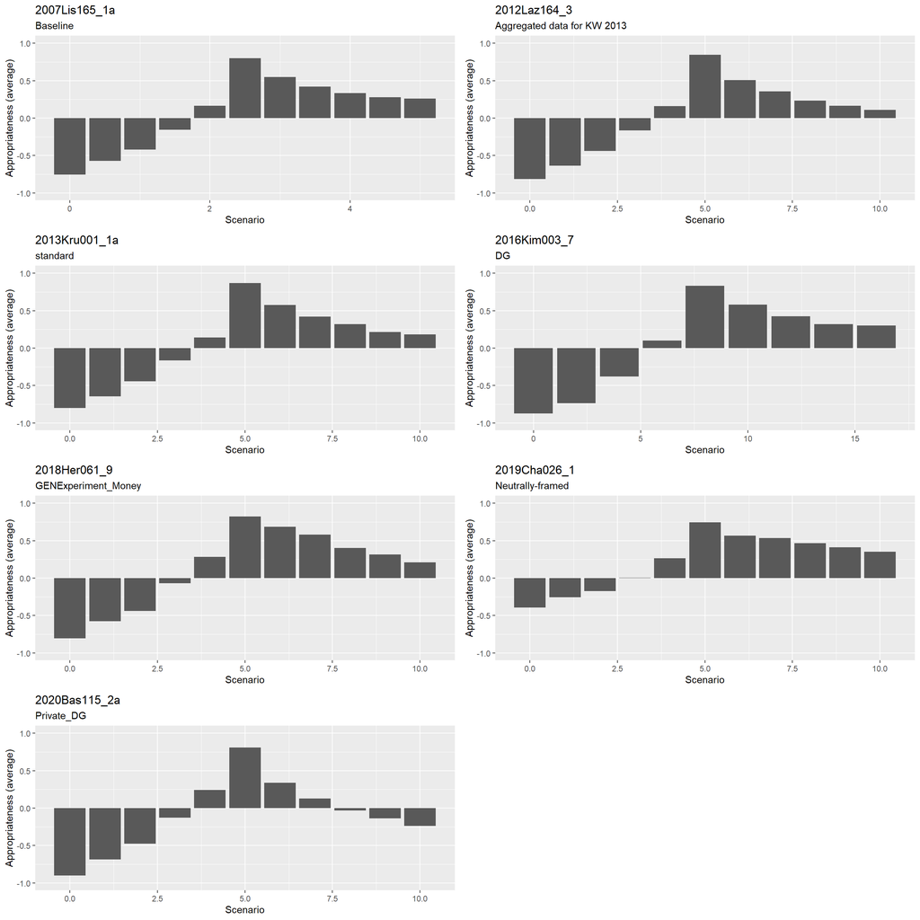

#### Choices

```
[1] 10 10 10 10 10 10 10 10
[1] 10 10 10 10 10 10
[1] 16 16 16 16 16 16 16 16
[1] 10 10 10 10 10 10 10 10
[1] 10 10 10 10 10 10 10 10
[1] 5 5 5 5 5 5 5
[1] 10 10 10 10 10 10 10 10 10
```

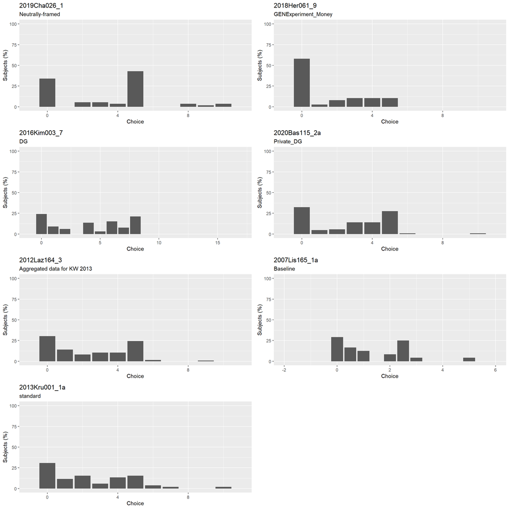

### Consistency and Specificity

#### Consistency

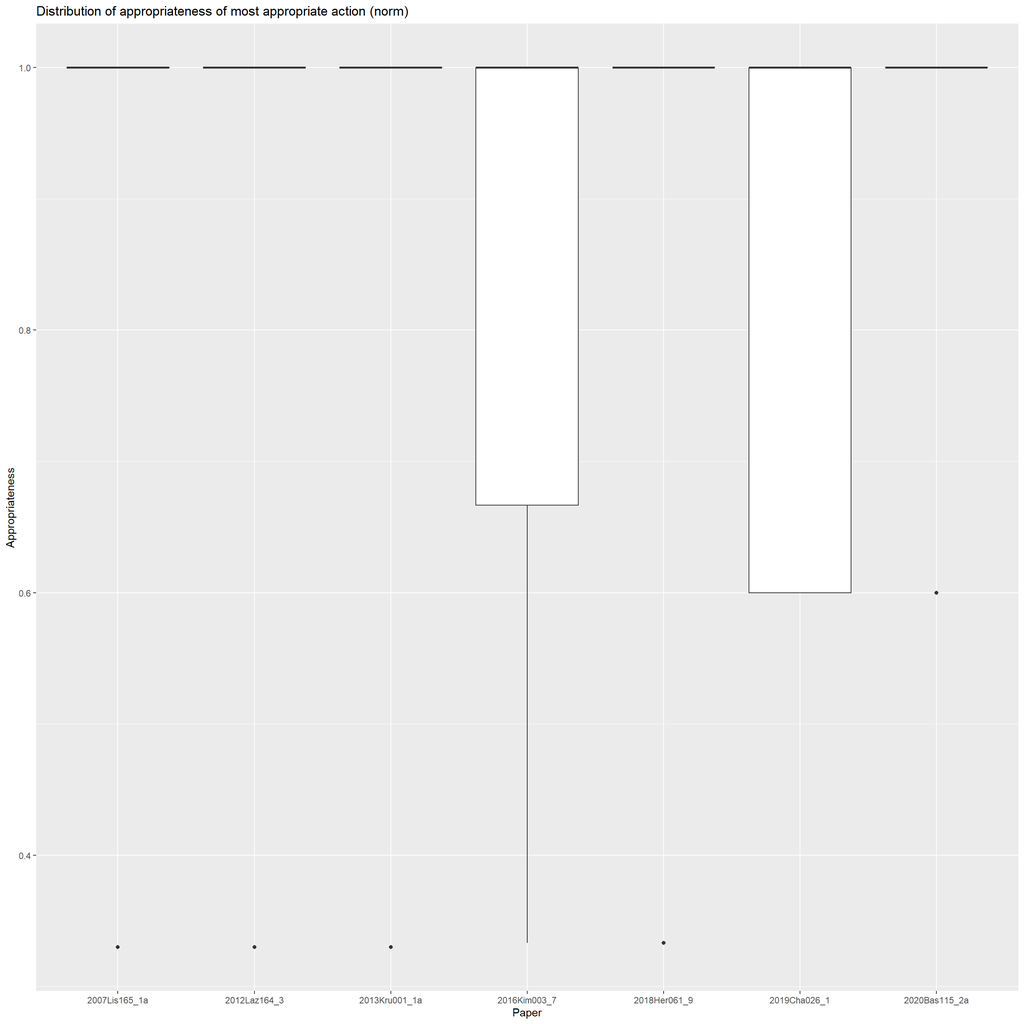

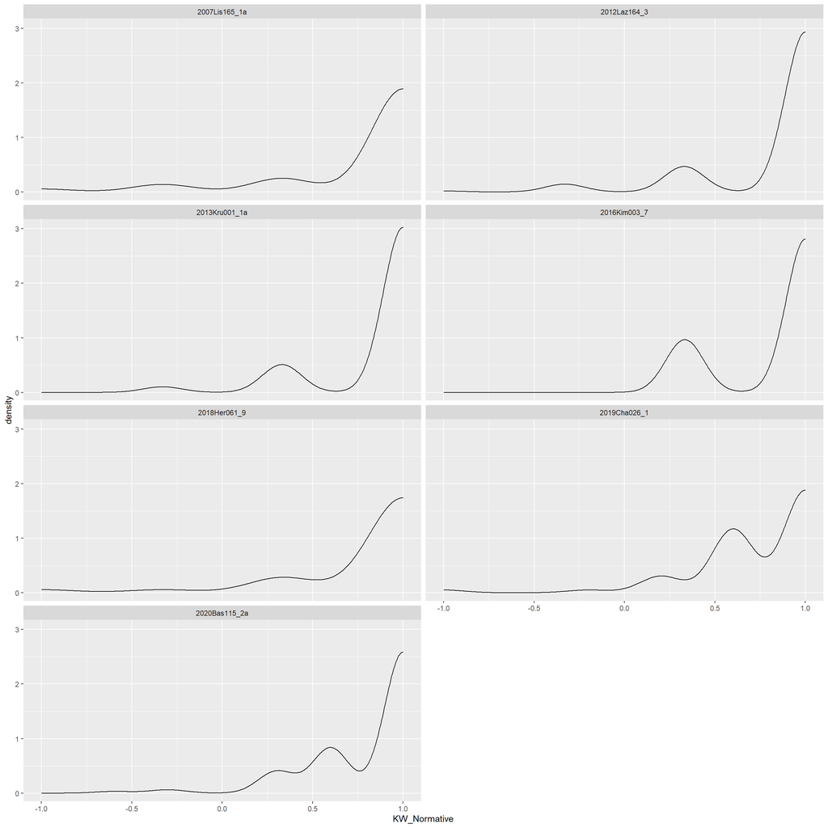

#### Specificity

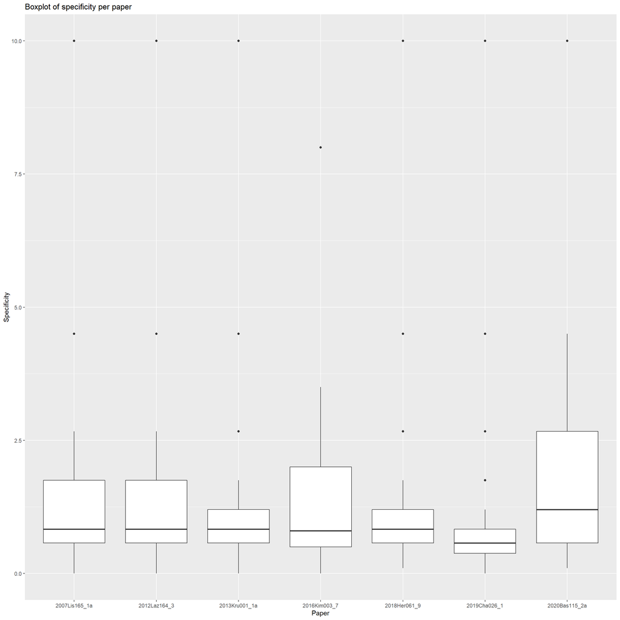

### Individual-level analyses

#### Social Expectation Model

$U_{ik} = \delta \pi_k + \gamma A_k + \epsilon_{ik}$

- $\pi_k$ indicates the payoff
- $A_k$ indicates the norm appropriateness

Coefficients for Social Expectation model

| paper | delta | gamma | SE_delta | SE_gamma | MRS |
| --- | --- | --- | --- | --- | --- |
| 2007Lis165_1a | 1.4150 | 2.1633 | 0.4870 | 0.9185 | 3.0578 |
| 2012Laz164_3 | 1.0912 | 3.1985 | 0.1458 | 0.4618 | 5.8621 |
| 2013Kru001_1a | 0.6162 | 1.5078 | 0.1549 | 0.5736 | 4.8942 |
| 2016Kim003_7 | 0.9523 | 4.3492 | 0.1647 | 0.7953 | 9.1338 |
| 2018Her061_9 | 1.8670 | 4.9146 | 0.5111 | 1.6665 | 5.2647 |
| 2019Cha026_1 | 0.7640 | 3.9580 | 0.1478 | 0.7183 | 10.3610 |
| 2020Bas115_2a | 1.1712 | 3.5357 | 0.1894 | 0.5628 | 6.0377 |

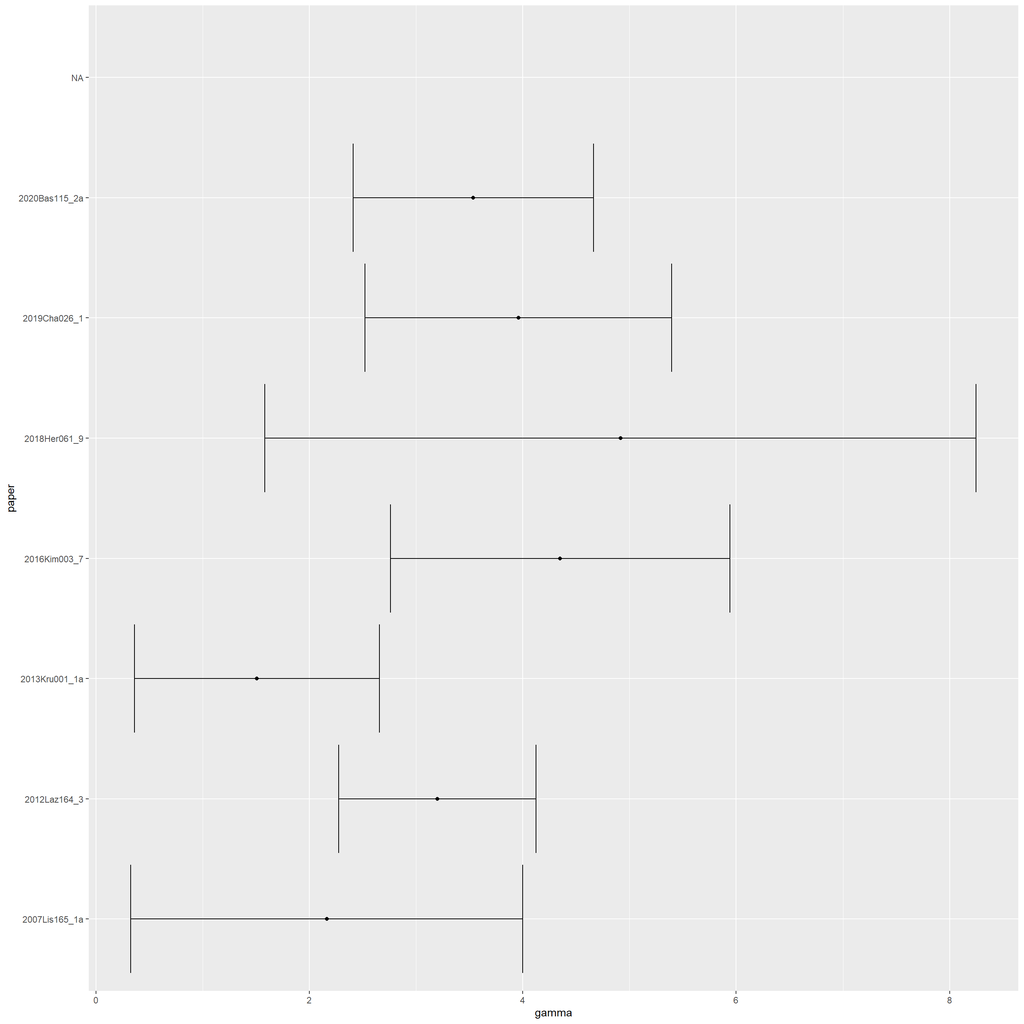

**Model Estimates**  
*Standard*

Model estimates for social expectation

|  | 2007Lis165_1a |  |  | 2012Laz164_3 |  |  | 2013Kru001_1a |  |  | 2016Kim003_7 |  |  | 2018Her061_9 |  |  | 2019Cha026_1 |  |  | 2020Bas115_2a |  |  |
| --- | --- | --- | --- | --- | --- | --- | --- | --- | --- | --- | --- | --- | --- | --- | --- | --- | --- | --- | --- | --- | --- |
| Predictors | Estimates | std. Error | p | Estimates | std. Error | p | Estimates | std. Error | p | Estimates | std. Error | p | Estimates | std. Error | p | Estimates | std. Error | p | Estimates | std. Error | p |
| payoff | 1.41 | 0.49 | **0.004** | 1.09 | 0.15 | **<0.001** | 0.62 | 0.15 | **<0.001** | 0.95 | 0.16 | **<0.001** | 1.87 | 0.51 | **<0.001** | 0.76 | 0.15 | **<0.001** | 1.17 | 0.19 | **<0.001** |
| mean app | 2.16 | 0.92 | **0.019** | 3.20 | 0.46 | **<0.001** | 1.51 | 0.57 | **0.009** | 4.35 | 0.80 | **<0.001** | 4.91 | 1.67 | **0.003** | 3.96 | 0.72 | **<0.001** | 3.54 | 0.56 | **<0.001** |
| Observations | 24 |  |  | 135 |  |  | 52 |  |  | 66 |  |  | 38 |  |  | 56 |  |  | 127 |  |  |
| AIC | 99.034 |  |  | 487.923 |  |  | 210.021 |  |  | 289.306 |  |  | 119.228 |  |  | 221.738 |  |  | 457.098 |  |  |
| log-Likelihood | -82.116 |  |  | -667.204 |  |  | -209.697 |  |  | -292.491 |  |  | -145.548 |  |  | -251.837 |  |  | -631.668 |  |  |

*Gender*

Model estimates for social expectation with gender

|  | 2016Kim003_7 |  |  | 2019Cha026_1 |  |  | 2020Bas115_2a |  |  |
| --- | --- | --- | --- | --- | --- | --- | --- | --- | --- |
| Predictors | Estimates | std. Error | p | Estimates | std. Error | p | Estimates | std. Error | p |
| payoff | 0.95 | 0.16 | **<0.001** | 0.76 | 0.15 | **<0.001** | 1.17 | 0.19 | **<0.001** |
| mean app | 4.18 | 0.82 | **<0.001** | 3.64 | 0.79 | **<0.001** | 3.43 | 0.59 | **<0.001** |
| mean app * female | 0.29 | 0.35 | 0.403 | 0.56 | 0.54 | 0.303 | 0.15 | 0.27 | 0.586 |
| Observations | 66 |  |  | 56 |  |  | 127 |  |  |
| AIC | 290.604 |  |  | 222.660 |  |  | 458.801 |  |  |
| log-Likelihood | -292.140 |  |  | -251.298 |  |  | -631.520 |  |  |

*Age*

Model estimates for social expectation with age

|  | 2016Kim003_7 |  |  | 2019Cha026_1 |  |  | 2020Bas115_2a |  |  |
| --- | --- | --- | --- | --- | --- | --- | --- | --- | --- |
| Predictors | Estimates | std. Error | p | Estimates | std. Error | p | Estimates | std. Error | p |
| payoff | 0.95 | 0.16 | **<0.001** | 0.76 | 0.15 | **<0.001** | 1.17 | 0.19 | **<0.001** |
| mean app | 2.18 | 2.25 | 0.331 | 3.73 | 1.12 | **0.001** | 3.08 | 0.74 | **<0.001** |
| mean app * age | 0.08 | 0.08 | 0.298 | 0.01 | 0.02 | 0.791 | 0.02 | 0.02 | 0.320 |
| Observations | 66 |  |  | 56 |  |  | 127 |  |  |
| AIC | 290.215 |  |  | 223.669 |  |  | 458.135 |  |  |
| log-Likelihood | -291.946 |  |  | -251.803 |  |  | -631.187 |  |  |

#### Social Expectation Augmented Model

$U_{ik} = \alpha \pi_k + \beta A_k + \delta C_k + \epsilon_{ik}$

- $\pi_k$ indicates the payoff
- $A_k$ indicates the norm appropriateness
- $C_k$ indicates the consistency

Model Estimates

|  | 2007Lis165_1a |  |  | 2012Laz164_3 |  |  | 2013Kru001_1a |  |  | 2016Kim003_7 |  |  | 2018Her061_9 |  |  | 2019Cha026_1 |  |  | 2020Bas115_2a |  |  |
| --- | --- | --- | --- | --- | --- | --- | --- | --- | --- | --- | --- | --- | --- | --- | --- | --- | --- | --- | --- | --- | --- |
| Predictors | Estimates | std. Error | p | Estimates | std. Error | p | Estimates | std. Error | p | Estimates | std. Error | p | Estimates | std. Error | p | Estimates | std. Error | p | Estimates | std. Error | p |
| payoff | 0.47 | 0.18 | **0.008** | 0.27 | 0.04 | **<0.001** | 0.33 | 0.07 | **<0.001** | 0.20 | 0.05 | **<0.001** | 0.72 | 0.19 | **<0.001** | 0.16 | 0.06 | **0.007** | 0.01 | 0.05 | 0.889 |
| sd app | -3.68 | 3.14 | 0.242 | -10.91 | 1.48 | **<0.001** | -4.88 | 2.10 | **0.021** | -5.90 | 1.82 | **0.001** | -8.42 | 4.58 | 0.066 | -4.04 | 1.29 | **0.002** | -11.22 | 1.70 | **<0.001** |
| Observations | 24 |  |  | 135 |  |  | 52 |  |  | 66 |  |  | 38 |  |  | 56 |  |  | 127 |  |  |
| AIC | 103.725 |  |  | 487.769 |  |  | 210.682 |  |  | 315.848 |  |  | 124.656 |  |  | 246.504 |  |  | 474.334 |  |  |
| log-Likelihood | -84.462 |  |  | -667.127 |  |  | -210.028 |  |  | -305.762 |  |  | -148.262 |  |  | -264.220 |  |  | -640.286 |  |  |

Model Estimates

|  | 2007Lis165_1a |  |  | 2012Laz164_3 |  |  | 2013Kru001_1a |  |  | 2016Kim003_7 |  |  | 2018Her061_9 |  |  | 2019Cha026_1 |  |  | 2020Bas115_2a |  |  |
| --- | --- | --- | --- | --- | --- | --- | --- | --- | --- | --- | --- | --- | --- | --- | --- | --- | --- | --- | --- | --- | --- |
| Predictors | Estimates | std. Error | p | Estimates | std. Error | p | Estimates | std. Error | p | Estimates | std. Error | p | Estimates | std. Error | p | Estimates | std. Error | p | Estimates | std. Error | p |
| payoff | 0.13 | 0.97 | 0.894 | 1.19 | 0.19 | **<0.001** | 0.66 | 0.30 | **0.027** | 1.24 | 0.30 | **<0.001** | 2.84 | 1.05 | **0.007** | -1.73 | 0.44 | **<0.001** | 1.24 | 0.24 | **<0.001** |
| mean app | 12.46 | 7.55 | 0.099 | 2.09 | 1.42 | 0.141 | 1.13 | 2.17 | 0.602 | 2.32 | 1.76 | 0.186 | -3.74 | 7.74 | 0.629 | 23.80 | 4.39 | **<0.001** | 2.53 | 2.17 | 0.245 |
| mean app * sd app | -24.07 | 17.33 | 0.165 | 3.38 | 4.12 | 0.412 | 1.24 | 6.95 | 0.859 | 9.29 | 7.49 | 0.215 | 24.77 | 22.16 | 0.264 | -70.56 | 14.37 | **<0.001** | 3.67 | 7.68 | 0.633 |
| Observations | 24 |  |  | 135 |  |  | 52 |  |  | 66 |  |  | 38 |  |  | 56 |  |  | 127 |  |  |
| AIC | 99.184 |  |  | 489.242 |  |  | 211.989 |  |  | 289.692 |  |  | 119.886 |  |  | 191.999 |  |  | 458.869 |  |  |
| log-Likelihood | -81.191 |  |  | -666.863 |  |  | -209.681 |  |  | -291.684 |  |  | -144.877 |  |  | -235.968 |  |  | -631.554 |  |  |

Model Estimates

|  | 2007Lis165_1a |  |  | 2012Laz164_3 |  |  | 2013Kru001_1a |  |  | 2016Kim003_7 |  |  | 2018Her061_9 |  |  | 2019Cha026_1 |  |  | 2020Bas115_2a |  |  |
| --- | --- | --- | --- | --- | --- | --- | --- | --- | --- | --- | --- | --- | --- | --- | --- | --- | --- | --- | --- | --- | --- |
| Predictors | Estimates | std. Error | p | Estimates | std. Error | p | Estimates | std. Error | p | Estimates | std. Error | p | Estimates | std. Error | p | Estimates | std. Error | p | Estimates | std. Error | p |
| payoff | 1.06 | 1.75 | 0.547 | 0.54 | 0.81 | 0.503 | 1.58 | 2.00 | 0.430 | 1.24 | 0.29 | **<0.001** | 3.90 | 1.19 | **0.001** | -1.14 | 0.55 | **0.039** | 1.91 | 0.49 | **<0.001** |
| mean app | 9.29 | 8.78 | 0.290 | 1.67 | 1.54 | 0.277 | 0.59 | 2.45 | 0.808 | 3.83 | 2.10 | 0.069 | 7.74 | 7.37 | 0.293 | 22.22 | 3.98 | **<0.001** | 6.27 | 3.13 | **0.045** |
| sd app | 4.85 | 7.90 | 0.540 | -7.05 | 8.71 | 0.419 | 10.11 | 21.70 | 0.641 | 4.16 | 3.17 | 0.190 | -19.80 | 7.38 | **0.007** | 4.55 | 3.47 | 0.190 | 9.14 | 5.56 | 0.100 |
| mean app * sd app | -14.38 | 22.55 | 0.524 | -1.42 | 7.23 | 0.844 | 12.32 | 24.76 | 0.619 | 6.10 | 7.84 | 0.436 | 4.59 | 18.84 | 0.808 | -59.08 | 14.42 | **<0.001** | -1.52 | 8.10 | 0.851 |
| Observations | 24 |  |  | 135 |  |  | 52 |  |  | 66 |  |  | 38 |  |  | 56 |  |  | 127 |  |  |
| AIC | 100.804 |  |  | 490.599 |  |  | 213.769 |  |  | 290.006 |  |  | 113.095 |  |  | 192.244 |  |  | 458.015 |  |  |
| log-Likelihood | -81.001 |  |  | -666.542 |  |  | -209.571 |  |  | -290.842 |  |  | -140.482 |  |  | -235.090 |  |  | -630.126 |  |  |

#### Inequality Aversion model (Fehr & Schimdt 1999)

$U_{ik} = \pi_k - \alpha*max( \pi_{jk} - \pi_{ik}) - \beta*max( \pi_{ik} - \pi_{jk})$

Model Estimates

|  | 2016Kim003_7 |  |  | 2018Her061_9 |  |  | 2019Cha026_1 |  |  | 2020Bas115_2a |  |  | 2007Lis165_1a |  |  | 2012Laz164_3 |  |  | 2013Kru001 |  |  |
| --- | --- | --- | --- | --- | --- | --- | --- | --- | --- | --- | --- | --- | --- | --- | --- | --- | --- | --- | --- | --- | --- |
| Predictors | Log-Odds | std. Error | p | Log-Odds | std. Error | p | Log-Odds | std. Error | p | Log-Odds | std. Error | p | Log-Odds | std. Error | p | Log-Odds | std. Error | p | Log-Odds | std. Error | p |
| other payoff ahead | -0.00 | 0.02 | 0.886 | 0.20 | 0.05 | **<0.001** | -0.01 | 0.04 | 0.786 | -0.00 | 0.03 | 0.942 | 0.16 | 0.12 | 0.210 | 0.04 | 0.03 | 0.117 | 0.09 | 0.04 | **0.042** |
| other payoff behind | -8.77 | 1167.75 | 0.994 | -7.95 | 1023.86 | 0.994 | -0.28 | 0.08 | **<0.001** | -0.83 | 0.18 | **<0.001** | -0.55 | 0.29 | 0.060 | -0.78 | 0.17 | **<0.001** | -0.34 | 0.12 | **0.005** |
| Observations | 1122 |  |  | 418 |  |  | 616 |  |  | 1397 |  |  | 264 |  |  | 1485 |  |  | 572 |  |  |
| AIC | 294.013 |  |  | 125.102 |  |  | 248.208 |  |  | 488.768 |  |  | 103.921 |  |  | 515.586 |  |  | 213.451 |  |  |
| log-Likelihood | -145.007 |  |  | -60.551 |  |  | -122.104 |  |  | -242.384 |  |  | -49.961 |  |  | -255.793 |  |  | -104.726 |  |  |

#### Inequality Aversion & Social Expectation model

$U_{ik} = \pi_k - \alpha*max( \pi_{jk} - \pi_{ik}) - \beta*max( \pi_{ik} - \pi_{jk}) +\delta A_k$

Model Estimates

|  | 2016Kim003_7 |  |  | 2018Her061_9 |  |  | 2019Cha026_1 |  |  | 2020Bas115_2a |  |  | 2007Lis165_1a |  |  | 2012Laz164_3 |  |  | 2013Kru001 |  |  |
| --- | --- | --- | --- | --- | --- | --- | --- | --- | --- | --- | --- | --- | --- | --- | --- | --- | --- | --- | --- | --- | --- |
| Predictors | Log-Odds | std. Error | p | Log-Odds | std. Error | p | Log-Odds | std. Error | p | Log-Odds | std. Error | p | Log-Odds | std. Error | p | Log-Odds | std. Error | p | Log-Odds | std. Error | p |
| other payoff ahead | 0.36 | 0.10 | **<0.001** | 0.86 | 0.27 | **0.002** | 1.15 | 0.22 | **<0.001** | 0.82 | 0.14 | **<0.001** | 1.57 | 0.54 | **0.004** | 0.54 | 0.10 | **<0.001** | 0.37 | 0.15 | **0.018** |
| other payoff behind | -8.97 | 1312.33 | 0.995 | -8.37 | 1353.50 | 0.995 | 0.04 | 0.11 | 0.683 | -0.14 | 0.19 | 0.457 | -0.13 | 0.33 | 0.698 | -0.56 | 0.18 | **0.002** | -0.26 | 0.13 | **0.045** |
| mean app | 3.38 | 0.89 | **<0.001** | 4.48 | 1.75 | **0.011** | 10.31 | 1.91 | **<0.001** | 4.87 | 0.83 | **<0.001** | 4.85 | 1.77 | **0.006** | 3.17 | 0.61 | **<0.001** | 1.84 | 0.96 | 0.055 |
| Observations | 1122 |  |  | 418 |  |  | 616 |  |  | 1397 |  |  | 264 |  |  | 1485 |  |  | 572 |  |  |
| AIC | 281.559 |  |  | 120.332 |  |  | 203.701 |  |  | 454.570 |  |  | 97.488 |  |  | 489.919 |  |  | 211.833 |  |  |
| log-Likelihood | -137.779 |  |  | -57.166 |  |  | -98.850 |  |  | -224.285 |  |  | -45.744 |  |  | -241.960 |  |  | -102.917 |  |  |

## Take or Give Game

List of paper after selection criteria applied

|  | PaperID | TreatmentCode | TreatmentName_paper | Year | Game_type | Standard_game | Baseline | Group_size | Rounds | Method_elicitation | Avg_coop | Avg_NE | Var_coop | Var_NE | Avg_KW_m |
| --- | --- | --- | --- | --- | --- | --- | --- | --- | --- | --- | --- | --- | --- | --- | --- |
| 1 | 2007Lis165 | 1b | Take 1$ | 2007 | ToG | Partially - limited take action |  | 2 | 1 | KW | 0.0174 | 0.5 | 0.0584 | 0.2053 | 0.7854 |
| 3 | 2019Cha026 | 3 | subset initial allocation 5-5 | 2019 | ToG | Subset |  | 2 | 11 | KW | 0.3263 | 0.5 | 0.0837 | 0.0942 | 0.7667 |
| 4 | 2013Kru001 | 1b | bully | 2013 | ToG | no check |  | 2 | 1 | KW | 0.3111 | 0.5 | 0.0712 | 0.0440 | 0.9272 |

### Descriptive Plots

#### Beliefs

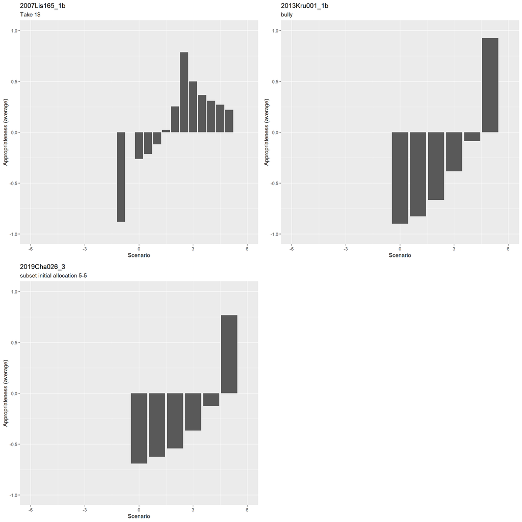

#### Choices

```
 [1] 5 5 5 5 5 5 5 5 5 5
[1] 5 5 5 5 5 5 5 5
[1] 10 10 10 10 10 10 10 10 10
```

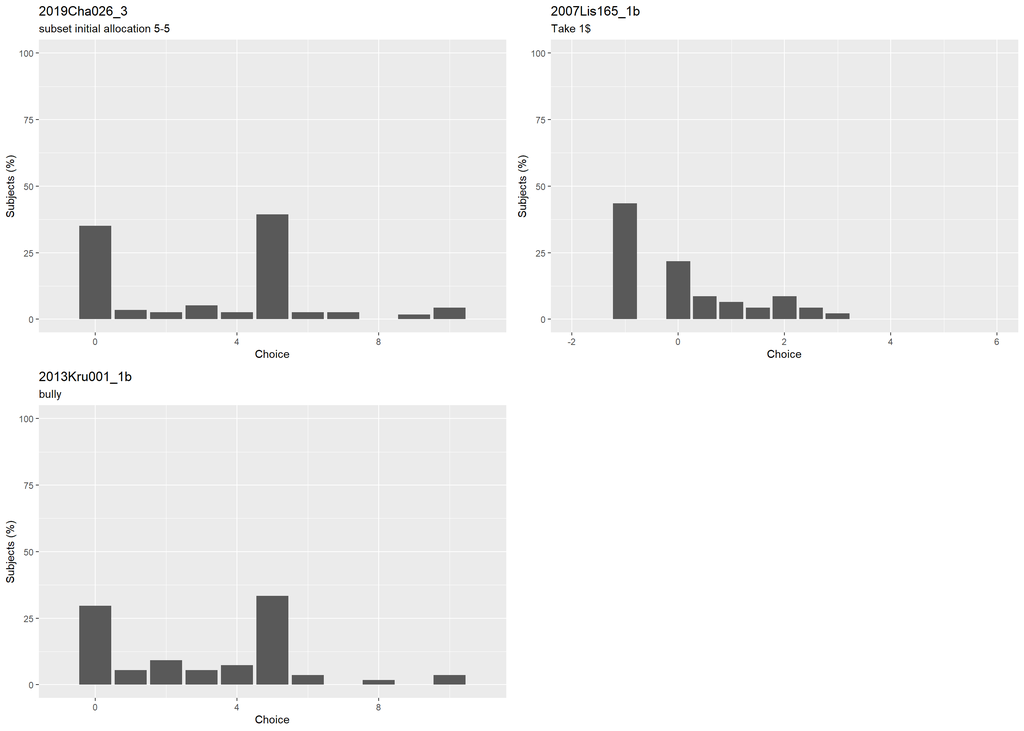

### Consistency and Specificity

#### Consistency

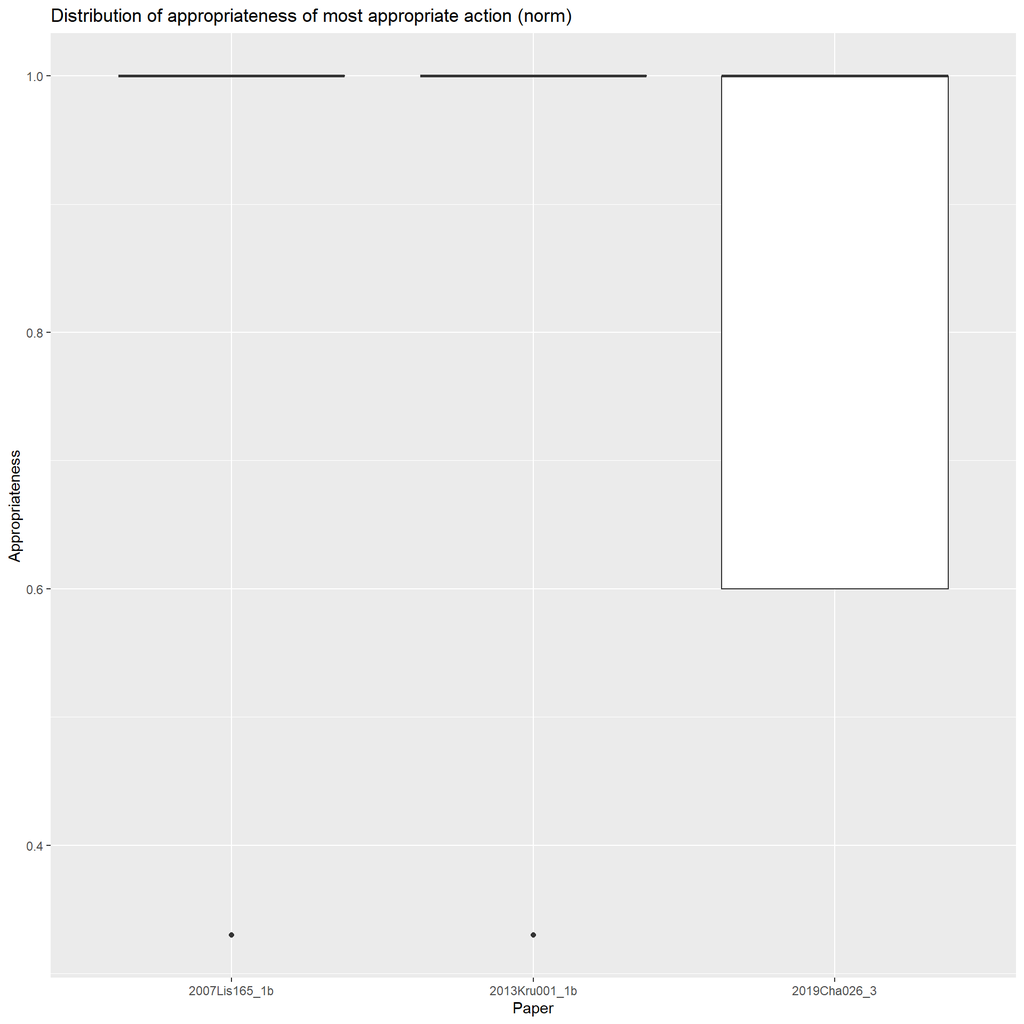

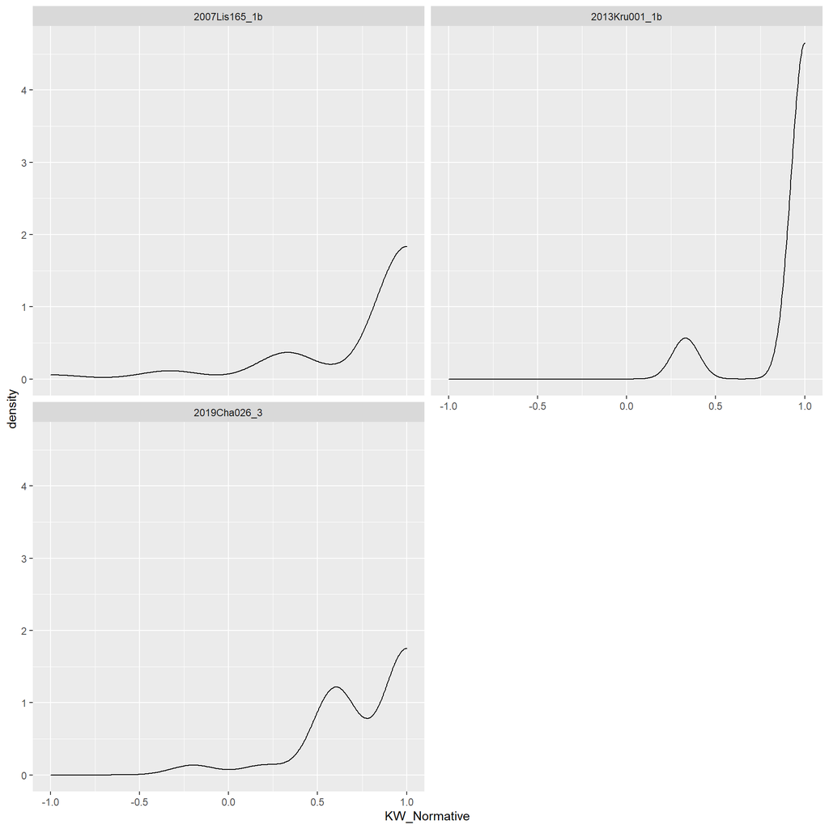

#### Specificity

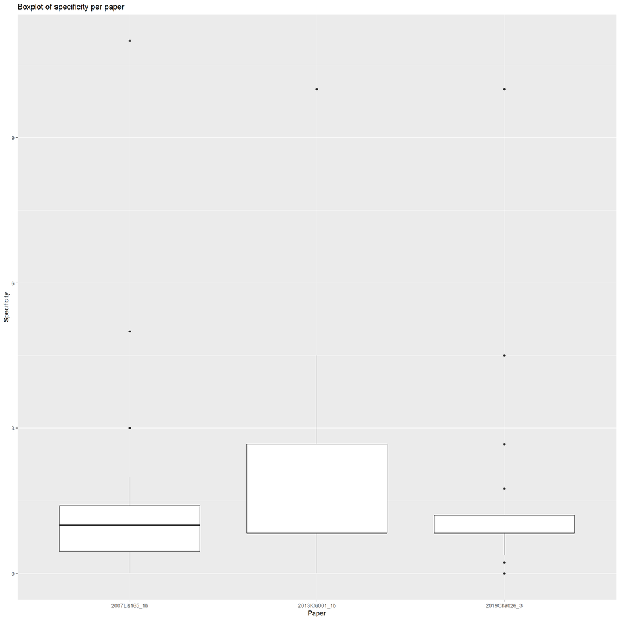

### Individual-level analysis

#### Social Expectation Model

$U_{ik} = \delta \pi_k + \gamma A_k + \epsilon_{ik}$

- $\pi_k$ indicates the payoff
- $A_k$ indicates the norm appropriateness

Coefficients for Social Expectation model

| paper | delta | gamma | SE_delta | SE_gamma | MRS |
| --- | --- | --- | --- | --- | --- |
| 2007Lis165_1b | 1.2333 | 1.1634 | 0.4065 | 1.0374 | 1.8868 |
| 2013Kru001_1b | 0.6389 | 1.9523 | 0.1221 | 0.3686 | 6.1112 |
| 2019Cha026_3 | 0.8136 | 3.1134 | 0.0938 | 0.3445 | 7.6532 |

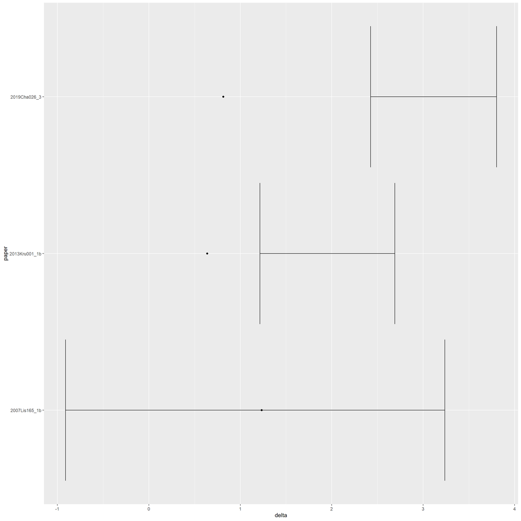

**Model Estimates**  
*Standard*

Model estimates for social expectation

|  | 2007Lis165_1b |  |  | 2013Kru001_1b |  |  | 2019Cha026_3 |  |  |
| --- | --- | --- | --- | --- | --- | --- | --- | --- | --- |
| Predictors | Estimates | std. Error | p | Estimates | std. Error | p | Estimates | std. Error | p |
| payoff | 1.23 | 0.41 | **0.002** | 0.64 | 0.12 | **<0.001** | 0.81 | 0.09 | **<0.001** |
| mean app | 1.16 | 1.04 | 0.262 | 1.95 | 0.37 | **<0.001** | 3.11 | 0.34 | **<0.001** |
| Observations | 46 |  |  | 54 |  |  | 114 |  |  |
| AIC | 161.072 |  |  | 213.285 |  |  | 425.621 |  |  |
| log-Likelihood | -178.635 |  |  | -223.987 |  |  | -568.578 |  |  |

*Gender*

Model estimates for social expectation with gender

|  | 2019Cha026_3 |  |  |
| --- | --- | --- | --- |
| Predictors | Estimates | std. Error | p |
| payoff | 0.81 | 0.09 | **<0.001** |
| mean app | 2.88 | 0.37 | **<0.001** |
| mean app * female | 0.50 | 0.29 | 0.084 |
| Observations | 114 |  |  |
| AIC | 424.599 |  |  |
| log-Likelihood | -567.067 |  |  |

*Age*

Model estimates for social expectation with age

|  | 2019Cha026_3 |  |  |
| --- | --- | --- | --- |
| Predictors | Estimates | std. Error | p |
| payoff | 0.81 | 0.09 | **<0.001** |
| mean app | 3.51 | 0.56 | **<0.001** |
| mean app * age | -0.01 | 0.01 | 0.374 |
| Observations | 114 |  |  |
| AIC | 426.827 |  |  |
| log-Likelihood | -568.181 |  |  |

#### Social Expectation Augmented Model

$U_{ik} = \alpha \pi_k + \beta A_k + \delta C_k + \epsilon_{ik}$

- $\pi_k$ indicates the payoff
- $A_k$ indicates the norm appropriateness
- $C_k$ indicates the standard deviation

Model Estimates sd_app

|  | 2007Lis165_1b |  |  | 2013Kru001_1b |  |  | 2019Cha026_3 |  |  |
| --- | --- | --- | --- | --- | --- | --- | --- | --- | --- |
| Predictors | Estimates | std. Error | p | Estimates | std. Error | p | Estimates | std. Error | p |
| payoff | 0.79 | 0.13 | **<0.001** | 0.09 | 0.06 | 0.120 | 0.16 | 0.04 | **<0.001** |
| sd app | -0.54 | 1.08 | 0.620 | -5.69 | 1.01 | **<0.001** | -4.27 | 1.35 | **0.002** |
| Observations | 46 |  |  | 54 |  |  | 114 |  |  |
| AIC | 162.178 |  |  | 212.148 |  |  | 504.875 |  |  |
| log-Likelihood | -179.188 |  |  | -223.419 |  |  | -608.205 |  |  |

Model Estimates mean_app:sd_app

|  | 2007Lis165_1b |  |  | 2013Kru001_1b |  |  | 2019Cha026_3 |  |  |
| --- | --- | --- | --- | --- | --- | --- | --- | --- | --- |
| Predictors | Estimates | std. Error | p | Estimates | std. Error | p | Estimates | std. Error | p |
| payoff | 1.67 | 0.60 | **0.005** | 0.53 | 0.18 | **0.002** | -0.42 | 0.27 | 0.127 |
| mean app | 0.44 | 1.31 | 0.736 | 2.56 | 0.88 | **0.003** | 14.87 | 2.73 | **<0.001** |
| mean app * sd app | 4.40 | 4.14 | 0.288 | -2.82 | 3.61 | 0.435 | -41.14 | 9.18 | **<0.001** |
| Observations | 46 |  |  | 54 |  |  | 114 |  |  |
| AIC | 161.987 |  |  | 214.643 |  |  | 397.119 |  |  |
| log-Likelihood | -178.093 |  |  | -223.666 |  |  | -553.327 |  |  |

Model Estimates mean_app:sd_app

|  | 2007Lis165_1b |  |  | 2013Kru001_1b |  |  | 2019Cha026_3 |  |  |
| --- | --- | --- | --- | --- | --- | --- | --- | --- | --- |
| Predictors | Estimates | std. Error | p | Estimates | std. Error | p | Estimates | std. Error | p |
| payoff | 1.24 | 0.79 | 0.116 | 0.21 | 0.44 | 0.627 | 0.31 | 0.44 | 0.479 |
| mean app | 3.94 | 4.68 | 0.400 | 0.43 | 2.88 | 0.881 | 11.96 | 3.19 | **<0.001** |
| sd app | -3.02 | 3.70 | 0.415 | -4.47 | 5.76 | 0.438 | 8.67 | 3.73 | **0.020** |
| mean app * sd app | -5.76 | 13.12 | 0.661 | 0.02 | 5.20 | 0.997 | -24.97 | 12.14 | **0.040** |
| Observations | 46 |  |  | 54 |  |  | 114 |  |  |
| AIC | 163.234 |  |  | 216.047 |  |  | 393.405 |  |  |
| log-Likelihood | -177.716 |  |  | -223.368 |  |  | -550.470 |  |  |

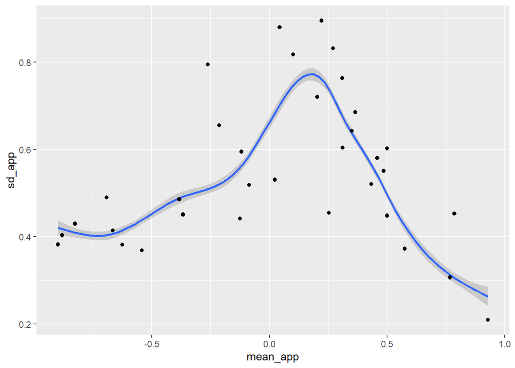

#### Inequality Aversion model (Fehr & Schimdt 1999)

$U_{ik} = \pi_k - \alpha*max( \pi_{jk} - \pi_{ik}) - \beta*max( \pi_{ik} - \pi_{jk})$

Model Estimates

|  | 2007Lis165_1b |  |  | 2013Kru001_1b |  |  | 2019Cha026_3 |  |  |
| --- | --- | --- | --- | --- | --- | --- | --- | --- | --- |
| Predictors | Log-Odds | std. Error | p | Log-Odds | std. Error | p | Log-Odds | std. Error | p |
| other payoff ahead | 0.36 | 0.07 | **<0.001** | 0.01 | 0.04 | 0.874 | 0.23 | 0.06 | **<0.001** |
| other payoff behind | -1.16 | 0.76 | 0.129 | -0.32 | 0.09 | **0.001** | -0.04 | 0.03 | 0.118 |
| Observations | 552 |  |  | 594 |  |  | 1254 |  |  |
| AIC | 160.451 |  |  | 234.399 |  |  | 508.731 |  |  |
| log-Likelihood | -78.226 |  |  | -115.200 |  |  | -252.366 |  |  |

## Donation Game

List of paper after selection criteria applied

| PaperID | TreatmentCode | TreatmentName_paper | Year | Game_type | Standard_game | Baseline | Group_size | Rounds | Method_elicitation | Avg_coop | Avg_NE | Var_coop | Var_NE | Avg_KW_m |
| --- | --- | --- | --- | --- | --- | --- | --- | --- | --- | --- | --- | --- | --- | --- |
| 2020And089 | 2 | EX1_PublicDecisionCondition | 2020 | Donation Game | Y |  | 4_8 | 1 | KW | 0.5672 | 1 | 0.1611 | 0.0807 | 0.8681 |
| 2020And089 | 1 | EX1_PrivateDecisionCondition | 2020 | Donation Game | Y |  | 4_8 | 1 | KW | 0.6010 | 1 | 0.1627 | 0.1502 | 0.8519 |

### Descriptive Plots

#### Beliefs

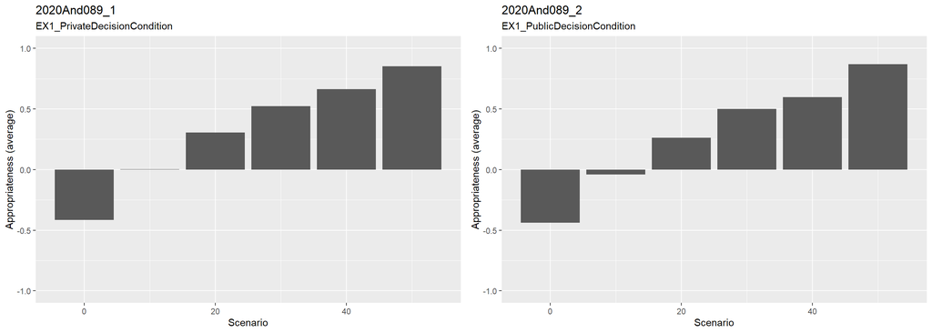

#### Choices

```
[1] 50 50 50 50 50 50
[1] 50 50 50 50 50 50
```

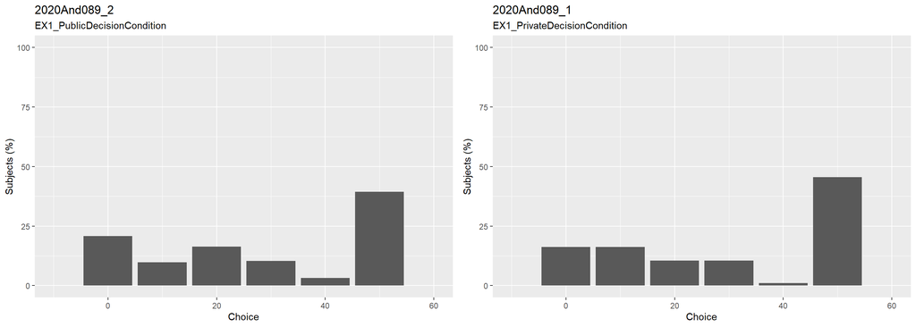

### Consistency and Specificity

#### Consistency

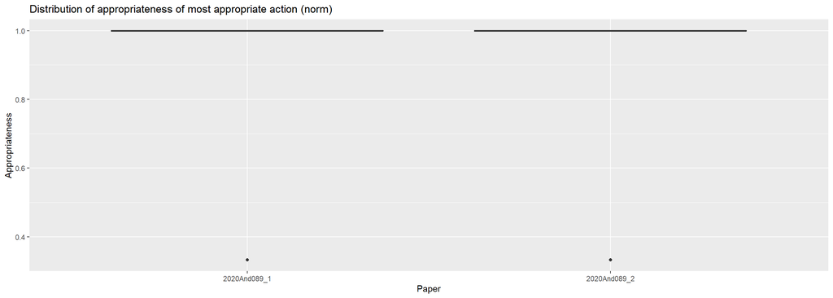

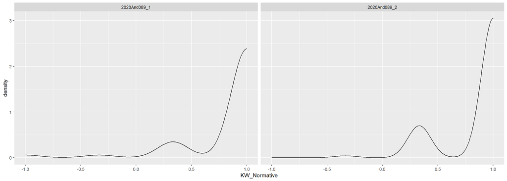

#### Specificity

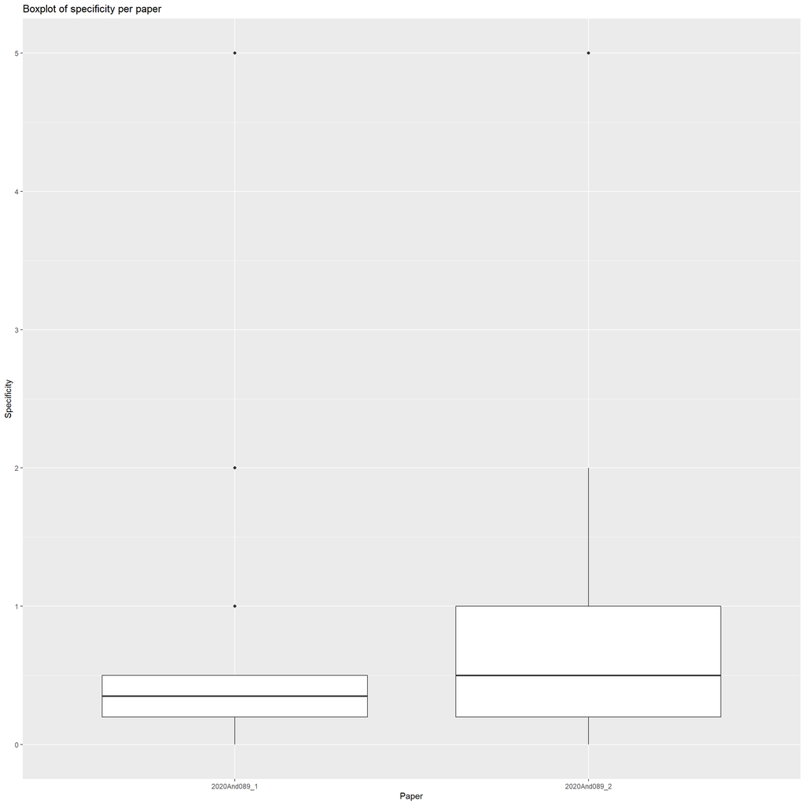

### Individual-level analyses

#### Social Expectation Model

$U_{ik} = \delta \pi_k + \gamma A_k + \epsilon_{ik}$

- $\pi_k$ indicates the payoff
- $A_k$ indicates the norm appropriateness

Coefficients for Social Expectation model

| paper | delta | gamma | SE_delta | SE_gamma | MRS |
| --- | --- | --- | --- | --- | --- |
| 2020And089_1 | -0.1192 | -4.2626 | 0.0218 | 0.8805 | 71.5152 |
| 2020And089_2 | -0.0728 | -2.5368 | 0.0225 | 0.9075 | 69.6997 |

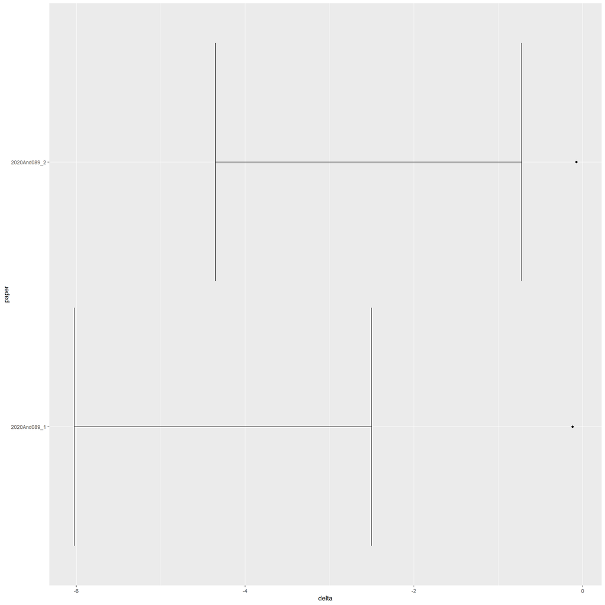

**Model Estimates**  
*Standard*

Model estimates for social expectation

|  | 2020And089_1 |  |  | 2020And089_2 |  |  |
| --- | --- | --- | --- | --- | --- | --- |
| Predictors | Estimates | std. Error | p | Estimates | std. Error | p |
| payoff | -0.12 | 0.02 | **<0.001** | -0.07 | 0.02 | **0.001** |
| mean app | -4.26 | 0.88 | **<0.001** | -2.54 | 0.91 | **0.005** |
| Observations | 191 |  |  | 183 |  |  |
| AIC | 647.613 |  |  | 644.759 |  |  |
| log-Likelihood | -1044.464 |  |  | -987.285 |  |  |

#### Social Expectation Augmented Model

$U_{ik} = \alpha \pi_k + \beta A_k + \delta C_k + \epsilon_{ik}$

- $\pi_k$ indicates the payoff
- $A_k$ indicates the norm appropriateness
- $C_k$ indicates the consistency

Model Estimates

|  | 2020And089_1 |  |  | 2020And089_2 |  |  |
| --- | --- | --- | --- | --- | --- | --- |
| Predictors | Estimates | std. Error | p | Estimates | std. Error | p |
| payoff | 0.04 | 0.01 | **<0.001** | 0.06 | 0.01 | **<0.001** |
| sd app | -18.33 | 2.54 | **<0.001** | -12.25 | 1.94 | **<0.001** |
| Observations | 191 |  |  | 183 |  |  |
| AIC | 606.713 |  |  | 589.463 |  |  |
| log-Likelihood | -1024.013 |  |  | -959.637 |  |  |

Model Estimates

|  | 2020And089_1 |  |  | 2020And089_2 |  |  |
| --- | --- | --- | --- | --- | --- | --- |
| Predictors | Estimates | std. Error | p | Estimates | std. Error | p |
| payoff | 0.15 | 0.04 | **0.001** | 0.10 | 0.04 | **0.014** |
| mean app | 21.36 | 3.96 | **<0.001** | 9.67 | 2.42 | **<0.001** |
| mean app * sd app | -33.29 | 5.18 | **<0.001** | -13.22 | 2.26 | **<0.001** |
| Observations | 191 |  |  | 183 |  |  |
| AIC | 577.968 |  |  | 583.488 |  |  |
| log-Likelihood | -1008.641 |  |  | -955.650 |  |  |

Model Estimates

|  | 2020And089_1 |  |  | 2020And089_2 |  |  |
| --- | --- | --- | --- | --- | --- | --- |
| Predictors | Estimates | std. Error | p | Estimates | std. Error | p |
| payoff | 0.16 | 0.04 | **<0.001** | 0.24 | 0.11 | **0.023** |
| mean app | 26.77 | 5.09 | **<0.001** | 27.20 | 12.43 | **0.029** |
| sd app | 8.27 | 5.10 | 0.105 | 18.09 | 12.51 | 0.148 |
| mean app * sd app | -42.37 | 7.51 | **<0.001** | -33.38 | 14.21 | **0.019** |
| Observations | 191 |  |  | 183 |  |  |
| AIC | 577.352 |  |  | 583.352 |  |  |
| log-Likelihood | -1007.333 |  |  | -954.582 |  |  |

#### Inequality Aversion model (Fehr & Schimdt 1999)

$U_{ik} = \pi_k - \alpha*max( \pi_{jk} - \pi_{ik}) - \beta*max( \pi_{ik} - \pi_{jk})$

Model Estimates

|  | 2020And089_1 |  |  | 2020And089_2 |  |  |
| --- | --- | --- | --- | --- | --- | --- |
| Predictors | Log-Odds | std. Error | p | Log-Odds | std. Error | p |
| other payoff ahead | 0.03 | 0.01 | **<0.001** | 0.02 | 0.01 | **<0.001** |
| other payoff behind | 0.04 | 0.01 | **<0.001** | 0.03 | 0.01 | **<0.001** |
| Observations | 1146 |  |  | 1098 |  |  |
| AIC | 627.250 |  |  | 623.343 |  |  |
| log-Likelihood | -311.625 |  |  | -309.671 |  |  |

## AIC: Model Comparison

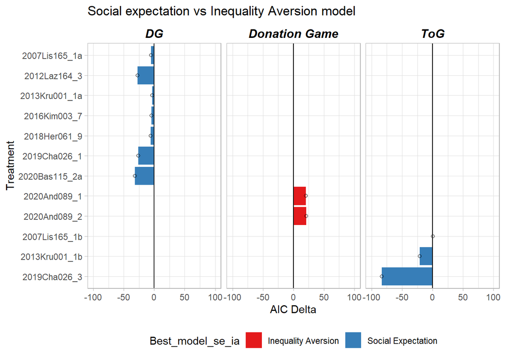

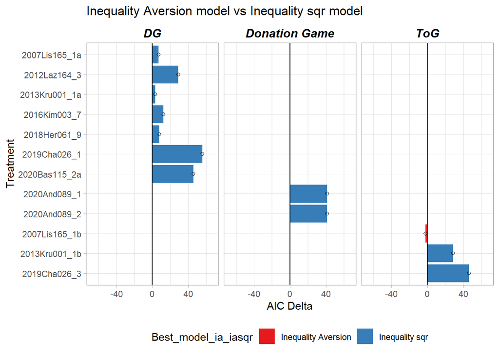

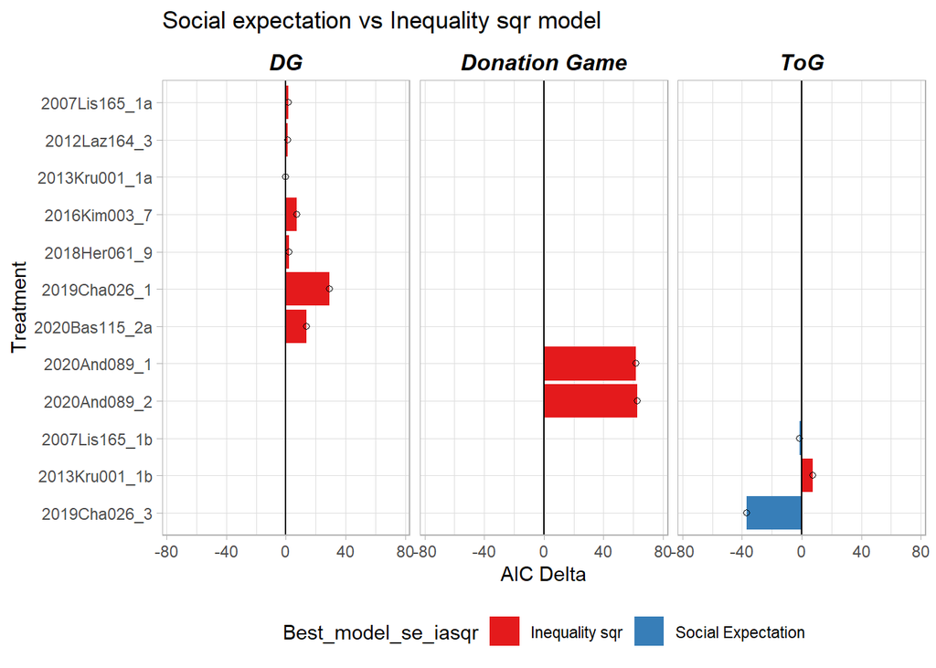

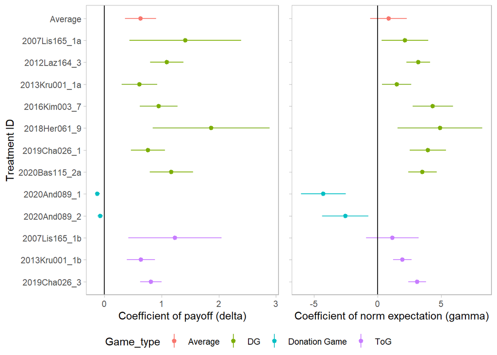

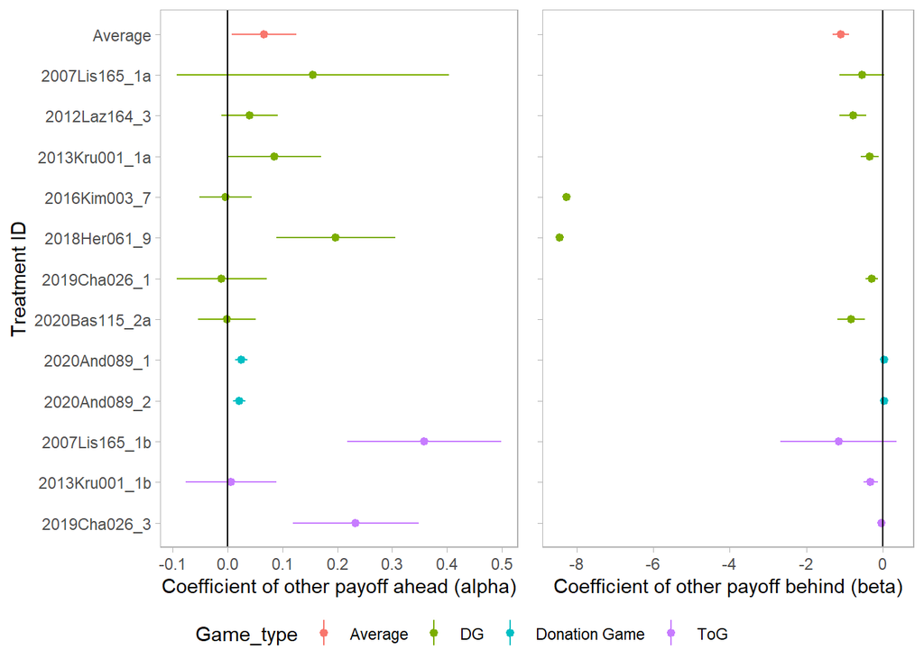

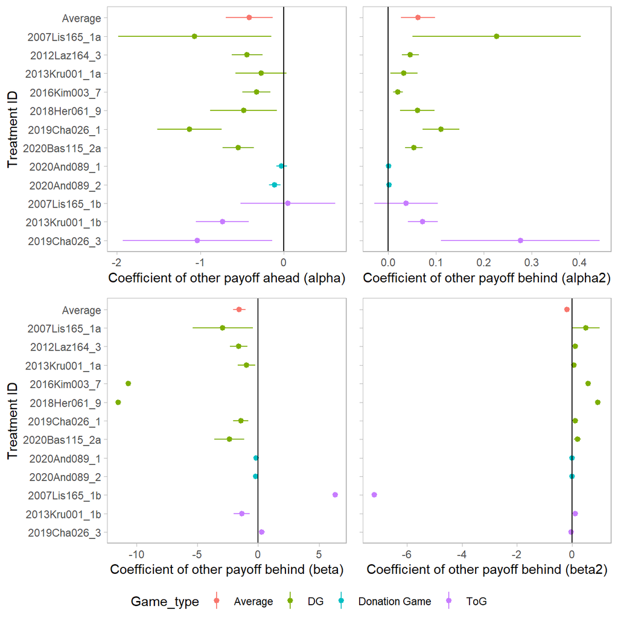